# Practical Machine Learning Final Project

Alva Presbitero

9/27/2019

## Practical Machine Learning Final Project

**Background**

Using devices such as Jawbone Up, Nike FuelBand, and Fitbit it is now possible to collect a large amount of data about personal activity relatively inexpensively. These type of devices are part of the quantified self movement – a group of enthusiasts who take measurements about themselves regularly to improve their health, to find patterns in their behavior, or because they are tech geeks. One thing that people regularly do is quantify how much of a particular activity they do, but they rarely quantify how well they do it. In this project, your goal will be to use data from accelerometers on the belt, forearm, arm, and dumbell of 6 participants. They were asked to perform barbell lifts correctly and incorrectly in 5 different ways. More information is available from the website here: http://web.archive.org/web/20161224072740/http:/groupware.les.inf.puc-rio.br/har (see the section on the Weight Lifting Exercise Dataset).

**Data**

The training data for this project are available here:

https://d396qusza40orc.cloudfront.net/predmachlearn/pml-training.csv

The test data are available here:

https://d396qusza40orc.cloudfront.net/predmachlearn/pml-testing.csv

The data for this project come from this source: http://web.archive.org/web/20161224072740/http:/groupware.les.inf.puc-rio.br/har. If you use the document you create for this class for any purpose please cite them as they have been very generous in allowing their data to be used for this kind of assignment.

## Reading the Data

Import necessary libraries

```r
library(RCurl)
library(caret)
```

Then we import and read the data. Since the data given is a url, we can easily import the data like so. We read the csv file using the read.csv command. Then we store the data in the trainng and testing variables as dataframes.

```r
url_train <- "https://d396qusza40orc.cloudfront.net/predmachlearn/pml-training.csv"
url_test <- "https://d396qusza40orc.cloudfront.net/predmachlearn/pml-testing.csv"

training <- read.csv(url_train)
testing <- read.csv(url_test)
```

For sanity check, we look at the dimensions of the dataframes for the training and test data sets that we have just read.

```r
dim(training); dim(testing);
```

```
## [1] 19622   160
```

```
## [1]  20 160
```

```r
View(training); View(testing);
```

As well as the distributions of the classes being predicted. I plot them below:

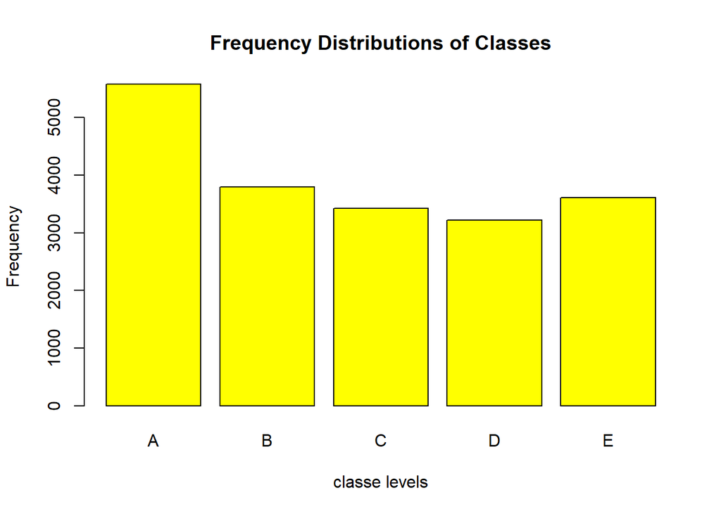

```r
plot(training$classe, col="yellow", main="Frequency Distributions of Classes", xlab="classe levels", ylab="Frequency")
```